# Lab 6

[Link to my Github Repository](https://github.com/bigturtle13/GSB544/tree/main/Week7)

**Import Packages**

```python
import pandas as pd
import numpy as np
from plotnine import *
from sklearn.pipeline import Pipeline
from sklearn.compose import make_column_selector, ColumnTransformer
from sklearn.preprocessing import StandardScaler, OneHotEncoder
from sklearn.linear_model import LinearRegression, Ridge, Lasso, ElasticNet
from sklearn.model_selection import cross_val_score, GridSearchCV
import matplotlib.pyplot as plt
from sklearn.metrics import *
import warnings
from sklearn.exceptions import ConvergenceWarning
warnings.filterwarnings("ignore", category=ConvergenceWarning)
```

**Part 0. Data Cleaning**

```python
df = pd.read_csv("/Users/amritdhillon/Desktop/GSB544/Week 6/Hitters.csv")
#fix any concerns with dataset

#na = df.isna().sum()
#print(na) had 59 na values in salary
#tot = len(df);tot # total number of observations
#percent missing
#m = 59/322;m
#About 18.3% of the data for Salaries is missing, this is a significant amount, rather than omitting the data, I will choose to impute it using the mean Salary
#Mean Salary
#meanSalary = np.mean(df['Salary']);meanSalary #meanSalary = 535.9258821292775
#Replace na values in Salary
#df['Salary']=df['Salary'].fillna(meanSalary)
#Recheck na values
#na = df.isna().sum()
#print(na) Now has 0 NAs

#This was my original strategy for fixing the missing values as to me 18.3% seemed like a large portion of the data; However, after talking to some classmates and doing some research, I found that its uncommon to impute the target variable itself as it can distort coefficient estimates and error metrics. This also ensures the model is only learning from observed outcomes not made up ones, if it was one of my features, it might be more reasonable to impute the 18.3% of values.

#instead I will drop the values
df = df.dropna(subset=['Salary']).copy()

X = df.drop("Salary", axis=1)
y = df["Salary"]
```

**Part I. Different Model Specs**

**A: Regression without regularization**

**1. Create a pipeline that includes all the columns as predictors for Salary, and performs ordinary linear regression**

```python
ct = ColumnTransformer(
    transformers = [
        ("dummify",
         OneHotEncoder(drop = "first", sparse_output=False, handle_unknown='ignore'),
         make_column_selector(dtype_include=object)),
        ("standardize",
         StandardScaler(),
         make_column_selector(dtype_include=np.number))
    ],
    remainder="passthrough"
)

lr_pipeline = Pipeline([
    ("preprocessing", ct),
    ("linear_regression", LinearRegression())
])
```

**2. Fit this pipeline to the full dataset, and interpret a few of the most important coefficients.**

```python
lr_pipeline.fit(X, y)

#extract OLS coefficients
coefs = lr_pipeline.named_steps["linear_regression"].coef_;coefs

featurenames = lr_pipeline.named_steps["preprocessing"].get_feature_names_out() # this gives us the actual names of each coefficient

df_coef = pd.DataFrame({"feature": featurenames, "coef": coefs}) #makes data frame with coefficient values and names mapped to each other

#strongest positive and negative coefficients for interpretation(top 4 for both)
print("Top 5 +/- coefficients (largest positive/or negative effects on Salary):")
print(df_coef.sort_values(by="coef", key=lambda s: np.abs(s), ascending=False).head(5))
```

```
Top 5 +/- coefficients (largest positive/or negative effects on Salary):
                feature        coef
13   standardize__CRuns  480.747135
10  standardize__CAtBat -391.038655
4     standardize__Hits  337.830479
3    standardize__AtBat -291.094556
14    standardize__CRBI  260.689886
```

- All else held constant, a one standard deviation increase in a player’s career runs is associated with a predicted 1987 salary about $480,747 higher.
- All else held constant, a one standard deviation increase in a player’s number of times at bat in his career is associated with a predicted 1987 salary about $391,038 less.
- All else held constant, a one standard deviation increase in a player’s number of hits in 1986 is associated with a predicted 1987 salary about $337,830 higher.
- All else held constant, a one standard deviation increase in a player’s number of times at bat in 1986 is associated with a predicted 1987 salary about $291,094 less.
- All else held constant, a one standard deviation increase in a player’s number of runs batted in during his career is associated with a predicted 1987 salary about $260,689 higher.

**3. Use cross-validation to estimate the MSE you would expect if you used this pipeline to predict 1989 salaries.**

```python
mse_lr = -cross_val_score(lr_pipeline, X, y,
                       cv=5,
                       scoring="neg_mean_squared_error")

rsquared_lr  = cross_val_score(lr_pipeline, X, y, #extra metrics I added for comparison later
                      cv=5,
                      scoring="r2")

print(f"Cross validated MSE: {mse_lr.mean():.3f}")
print(f"Cross validated R Squared : {rsquared_lr.mean():.3f}")
```

```
Cross validated MSE: 121136.310
Cross validated R Squared : 0.343
```

**B. Ridge regression**

**1. Create a pipeline that includes all the columns as predictors for Salary, and performs ordinary ridge regression**

```python
#ridge pipeline
ridge_pipeline = Pipeline(steps=[
    ("preprocessing", ct),
    ("ridge_regression", Ridge(max_iter=100000, alpha = 1))
]).set_output(transform="pandas")
```

**2. Use cross-validation to tune the λ hyperparameter.**

```python
alphas = {'ridge_regression__alpha': np.array([100, 10, 1, 0.1, 0.01])}

gscv = GridSearchCV(estimator = ridge_pipeline, param_grid=alphas, cv = 5, scoring='neg_mean_squared_error')

gscv.fit(X,y)

best_alpha = gscv.best_params_["ridge_regression__alpha"]
print(f"Best λ (alpha): {best_alpha:.4f}")
```

```
Best λ (alpha): 1.0000
```

**3. Fit the pipeline with your chosen λ to the full dataset, and interpret a few of the most important coefficients.**

```python
#similar concept to previous part, organized a table with the coefficients and the names of the coefficients
best_ridge_pipeline = gscv.best_estimator_
ridge_coefs = best_ridge_pipeline.named_steps["ridge_regression"].coef_
feature_names = best_ridge_pipeline.named_steps["preprocessing"].get_feature_names_out()
ridge_coef_df = pd.DataFrame({"feature": feature_names, "coef": ridge_coefs})

#strongest positive and negative coefficients for interpretation(top 5 for both)
print("Top 5 +/- coefficients (largest positive/or negative effects on Salary):")
print(ridge_coef_df.sort_values(by="coef", key=lambda s: np.abs(s), ascending=False).head(5))
```

```
Top 5 +/- coefficients (largest positive/or negative effects on Salary):
                feature        coef
13   standardize__CRuns  320.802717
4     standardize__Hits  296.801967
3    standardize__AtBat -271.088165
10  standardize__CAtBat -225.511649
15  standardize__CWalks -184.289408
```

- All else held constant, a one standard deviation increase in a player’s number of runs in his career is associated with a predicted 1987 salary about $320,802 higher.
- All else held constant, a one standard deviation increase in a player’s number of hits in 1986 is associated with a predicted 1987 salary about $296,801 higher.
- All else held constant, a one standard deviation increase in a player’s number of times at bat in 1986 is associated with a predicted 1987 salary about $271,088 less.
- All else held constant, a one standard deviation increase in a player’s number of times at bat during his career is associated with a predicted 1987 salary about $225,511 less.
- All else held constant, a one standard deviation increase in a player’s number of walks during his career is associated with a predicted 1987 salary about $184,289 less.

**4.Report the MSE you would expect if you used this pipeline to predict 1989 salaries.**

```python
mse_ridge = -cross_val_score(
    best_ridge_pipeline,
    X, y,
    cv=5,
    scoring="neg_mean_squared_error"
)
r2_ridge = cross_val_score( #extra metric I added
    best_ridge_pipeline,
    X, y,
    cv=5,
    scoring="r2"
)

print(f"Cross validated MSE (Ridge λ={best_alpha:.3f}): {mse_ridge.mean():.3f}")
print(f"Cross validated R squared (Ridge): {r2_ridge.mean():.3f}") #extra for comparison
```

```
Cross validated MSE (Ridge λ=1.000): 119034.333
Cross validated R squared (Ridge): 0.356
```

**C. Lasso Regression**

```python
#lasso pipeline
lasso_pipeline = Pipeline(steps=[
    ("preprocessing", ct),
    ("lasso_regression", Lasso(max_iter=100000, alpha = 1))
]).set_output(transform="pandas")
```

**2. Use cross-validation to tune the λ hyperparameter.**

```python
alphas = {'lasso_regression__alpha': np.array([100, 10, 1, 0.1, 0.01])}

lasso_gscv = GridSearchCV(
    estimator=lasso_pipeline,
    param_grid=alphas,
    cv=5,
    scoring="neg_mean_squared_error"
)

lasso_gscv.fit(X, y)

best_alpha_lasso = lasso_gscv.best_params_['lasso_regression__alpha']
print(f"Best λ (alpha) for LASSO: {best_alpha_lasso}")
```

```
Best λ (alpha) for LASSO: 1.0
```

**3. Fit the pipeline with your chosen λ to the full dataset, and interpret a few of the most important coefficients.**

```python
best_lasso_pipeline = lasso_gscv.best_estimator_
lasso_coefs = best_lasso_pipeline.named_steps["lasso_regression"].coef_
feature_names = best_lasso_pipeline.named_steps["preprocessing"].get_feature_names_out()
lasso_coef_df = pd.DataFrame({"feature": feature_names, "coef": lasso_coefs})

#strongest positive and negative coefficients for interpretation(top 5 for both)
print("Top 5 +/- coefficients (largest positive/or negative effects on Salary):")
print(lasso_coef_df.sort_values(by="coef", key=lambda s: np.abs(s), ascending=False).head(5))
```

```
Top 5 +/- coefficients (largest positive/or negative effects on Salary):
                feature        coef
13   standardize__CRuns  375.565519
4     standardize__Hits  304.359509
3    standardize__AtBat -282.370957
14    standardize__CRBI  192.610892
15  standardize__CWalks -189.644642
```

- All else held constant, a one standard deviation increase in a player’s number of runs during his career is associated with a predicted 1987 salary about $375,565 higher.
- All else held constant, a one standard deviation increase in a player’s number of hits in 1986 is associated with a predicted 1987 salary about $304,359 higher.
- All else held constant, a one standard deviation increase in a player’s times at bat in 1986 is associated with a predicted 1987 salary about $282,370 lower.
- All else held constant, a one standard deviation increase in a player’s number of runs batted in during his career is associated with a predicted 1987 salary about $192,610 higher.
- All else held constant, a one standard deviation increase in a player’s number of walks during his career is associated with a predicted 1987 salary about $189,644 lower.

**4.Report the MSE you would expect if you used this pipeline to predict 1989 salaries.**

```python
mse_lasso = -cross_val_score(
    best_lasso_pipeline,
    X, y,
    cv=5,
    scoring="neg_mean_squared_error"
)
r2_lasso = cross_val_score( #extra metric I added
    best_lasso_pipeline,
    X, y,
    cv=5,
    scoring="r2"
)

print(f"Cross validated MSE (Lasso λ={best_alpha_lasso:.3f}): {mse_lasso.mean():.3f}")
print(f"Cross validated R squared (Lasso): {r2_lasso.mean():.3f}") #extra for comparison
```

```
Cross validated MSE (Lasso λ=1.000): 119758.109
Cross validated R squared (Lasso): 0.354
```

**D. Elastic Net**

```python
#elastic pipeline
elastic_pipeline = Pipeline(steps=[
    ("preprocessing", ct),
    ("elastic_regression", ElasticNet(max_iter=100000, alpha = 1))
]).set_output(transform="pandas")
```

**2. Use cross-validation to tune the λ and α hyperparameters.**

```python
param_grid = {
    'elastic_regression__alpha': [0.001, 0.01, 0.1, 1, 10, 100],
    'elastic_regression__l1_ratio': [0.0, 0.2, 0.4, 0.6, 0.8, 1.0]
}
elasticgrid = GridSearchCV(elastic_pipeline, param_grid, cv=5, scoring='neg_mean_squared_error')
elasticgrid.fit(X, y)

best_alpha_elastic = elasticgrid.best_params_['elastic_regression__alpha']
best_l1ratio_elastic = elasticgrid.best_params_['elastic_regression__l1_ratio']
print(f"Best λ (alpha) for Elastic Net: {best_alpha_elastic:.3f}")
print(f"Best α (l1_ratio) for Elastic Net: {best_l1ratio_elastic:.3f}")
```

```
Best λ (alpha) for Elastic Net: 0.100
Best α (l1_ratio) for Elastic Net: 0.800
```

**3. Fit the pipeline with your chosen λ and α to the full dataset, and interpret a few of the most important coefficients.**

```python
best_elastic_pipeline = elasticgrid.best_estimator_
elastic_coefs = best_elastic_pipeline.named_steps["elastic_regression"].coef_
feature_names = best_elastic_pipeline.named_steps["preprocessing"].get_feature_names_out()
elastic_coef_df = pd.DataFrame({"feature": feature_names, "coef": elastic_coefs})

#strongest positive and negative coefficients for interpretation(top 5 for both)
print("Top 5 +/- coefficients (largest positive/or negative effects on Salary):")
print(elastic_coef_df.sort_values(by="coef", key=lambda s: np.abs(s), ascending=False).head(5))
```

```
Top 5 +/- coefficients (largest positive/or negative effects on Salary):
                feature        coef
4     standardize__Hits  200.830729
3    standardize__AtBat -186.181515
13   standardize__CRuns  163.907498
15  standardize__CWalks -125.175493
1   dummify__Division_W -116.818145
```

- All else held constant, a one standard deviation increase in a player’s number of hits in 1986 is associated with a predicted 1987 salary about $200,830 higher.
- All else held constant, a one standard deviation increase in a player’s number of times at bat in 1986 is associated with a predicted 1987 salary about $186,181 less.
- All else held constant, a one standard deviation increase in a player’s number of runs during his career is associated with a predicted 1987 salary about $163,907 higher.
- All else held constant, a one standard deviation increase in a player’s number of walks during his career is associated with a predicted 1987 salary about $125,175 less.
- All else held constant, a player being a part of the West Division at the end of 1986 is associated with a predicted 1987 salary about $116,818 less.

**4.Report the MSE you would expect if you used this pipeline to predict 1989 salaries.**

```python
mse_elastic = -cross_val_score(
    best_elastic_pipeline,
    X, y,
    cv=5,
    scoring="neg_mean_squared_error"
)
r2_elastic = cross_val_score( #extra metric I added
    best_elastic_pipeline,
    X, y,
    cv=5,
    scoring="r2"
)

print(f"Cross validated MSE (Elastic λ={best_alpha_elastic:.3f}, Elastic α ={best_l1ratio_elastic:.3f}): {mse_elastic.mean():.3f}")
print(f"Cross validated R squared (Elastic): {r2_elastic.mean():.3f}") #extra for comparison
```

```
Cross validated MSE (Elastic λ=0.100, Elastic α =0.800): 118750.189
Cross validated R squared (Elastic): 0.365
```

**Initial Comparison of Model MSE Values**

```python
mse_compare = pd.DataFrame({
    'Model': ['OLS', 'Ridge', 'LASSO', 'Elastic Net'],
    'Cross Validated MSE': [
        mse_lr.mean(),
        mse_ridge.mean(),
        mse_lasso.mean(),
        mse_elastic.mean()]});mse_compare.sort_values(by='Cross Validated MSE', ascending=True)
```

|  | Model | Cross Validated MSE |
| --- | --- | --- |
| 3 | Elastic Net | 118750.189196 |
| 1 | Ridge | 119034.332720 |
| 2 | LASSO | 119758.108873 |
| 0 | OLS | 121136.310318 |

The initial best model using all features is the Elastic Net model.

**Part II. Variable Selection**

Based on the above results, decide on:

Which numeric variable is most important.

Which five numeric variables are most important.

Which categorical variable is most important.

```python
coef_compare = pd.DataFrame({
    'Feature': featurenames,
    'lr': coefs,
    'ridge': ridge_coefs,
    'lasso': lasso_coefs,
    'elastic': elastic_coefs
})
```

**Which numeric variable is most important.**

```python
#create labels for each different type of variable using startswith
num_var = coef_compare["Feature"].str.startswith("standardize__")
cat_var = coef_compare["Feature"].str.startswith("dummify__")
numeric_coefs = coef_compare[num_var].copy()
categorical_coefs = coef_compare[cat_var].copy()

#make in terms of magnitudes rather than postitive/negative
for col in ['lr', 'ridge', 'lasso', 'elastic']:
    numeric_coefs[f'abs_{col}'] = numeric_coefs[col].abs()
    categorical_coefs[f'abs_{col}'] = categorical_coefs[col].abs()

# most important numeric variable per model, make new df
most_important_numeric = pd.DataFrame(columns=['Model', 'Feature', 'Coefficient'])

#find top variable for each model, store in df
#loops over each model
for model in ['lr', 'ridge', 'lasso', 'elastic']:
    abs_col = f'abs_{model}'
    #gets the largest abs value coefficient of each model
    top_row = numeric_coefs.loc[numeric_coefs[abs_col].idxmax()]
    #gets feature with that top id as well as coefficient
    most_important_numeric.loc[len(most_important_numeric)] = [
        model.upper(),
        top_row['Feature'],
        top_row[model]
    ]
#prints most important variable of each model
print("Most Important Numeric Variable (per model):")
print(most_important_numeric)
```

```
Most Important Numeric Variable (per model):
     Model             Feature  Coefficient
0       LR  standardize__CRuns   480.747135
1    RIDGE  standardize__CRuns   320.802717
2    LASSO  standardize__CRuns   375.565519
3  ELASTIC   standardize__Hits   200.830729
```

The most important numeric variable is CRuns(Number of runs during a player’s career). It is the most important coefficient in 3/4 of models.

**Which five numeric variables are most important.**

```python
#first i want to just see the top 5 variables in each to see if I can make it easy and rank myself
top5_numeric = {}
for model in ['lr', 'ridge', 'lasso', 'elastic']:
    top5 = (
        numeric_coefs.sort_values(f'abs_{model}', ascending=False).head(5)[['Feature', model]]
    )

    top5_numeric[model] = top5

    print(f"Top 5 Numeric Variables — {model.upper()}")
    print(top5.to_string(index=False))
    print()


#its hard to rank myself so i will rank based off of average absolute magnitude
```

```
Top 5 Numeric Variables — LR
            Feature          lr
 standardize__CRuns  480.747135
standardize__CAtBat -391.038655
  standardize__Hits  337.830479
 standardize__AtBat -291.094556
  standardize__CRBI  260.689886

Top 5 Numeric Variables — RIDGE
            Feature       ridge
 standardize__CRuns  320.802717
  standardize__Hits  296.801967
 standardize__AtBat -271.088165
standardize__CAtBat -225.511649
standardize__CWalks -184.289408

Top 5 Numeric Variables — LASSO
            Feature       lasso
 standardize__CRuns  375.565519
  standardize__Hits  304.359509
 standardize__AtBat -282.370957
  standardize__CRBI  192.610892
standardize__CWalks -189.644642

Top 5 Numeric Variables — ELASTIC
            Feature     elastic
  standardize__Hits  200.830729
 standardize__AtBat -186.181515
 standardize__CRuns  163.907498
standardize__CWalks -125.175493
 standardize__CHits  110.173426
```

Its hard to rank myself so I will rank based off of average absolute magnitude.

```python
coef_avg = coef_compare.copy()
models = ['lr', 'ridge', 'lasso', 'elastic']

#absolute values for each model
for m in models:
    coef_avg[f'abs_{m}'] = coef_avg[m].abs()
#average absolute magnitude for all models
coef_avg['avg_abs'] = coef_avg[[f'abs_{m}' for m in models]].mean(axis=1)

#sorted by average absolute value
coef_avg_sorted = coef_avg.sort_values('avg_abs', ascending=False)

#top 10 numeric variables by average absolute coefficient
top10_numeric_avg = (
    coef_avg_sorted[coef_avg_sorted['Feature'].str.startswith('standardize__')]
    [['Feature', 'avg_abs']]
    .head(10)
)

print("Top 10 Numeric Variables (by average absolute magnitude):")
print(top10_numeric_avg.to_string(index=False))

#printing confirms that the top 5 numeric variables ranked by average absolute
#magnitude are CRuns, Hits, AtBat, CAtBat, and CRBI.
```

```
Top 10 Numeric Variables (by average absolute magnitude):
             Feature    avg_abs
  standardize__CRuns 335.255717
   standardize__Hits 284.955671
  standardize__AtBat 257.683798
 standardize__CAtBat 209.148061
   standardize__CRBI 179.553688
 standardize__CWalks 178.250450
  standardize__Walks 119.363629
  standardize__CHits  80.767907
standardize__PutOuts  78.270018
standardize__Assists  44.578464
```

The top 5 numeric variables ranked by average absolute magnitude are CRuns, Hits, AtBat, CAtBat, and CRBI.

**Which categorical variable is most important.**

```python
most_important_categorical = pd.DataFrame(columns=['Model', 'Feature', 'Coefficient'])

for model in ['lr', 'ridge', 'lasso', 'elastic']:
    abs_col = f'abs_{model}'
    top_row = categorical_coefs.loc[categorical_coefs[abs_col].idxmax()]
    most_important_categorical.loc[len(most_important_categorical)] = [
        model.upper(),
        top_row['Feature'],
        top_row[model]
    ]

print("Most Important Categorical Variable (per model):")
print(most_important_categorical)
```

```
Most Important Categorical Variable (per model):
     Model              Feature  Coefficient
0       LR  dummify__Division_W  -116.849246
1    RIDGE  dummify__Division_W  -119.076927
2    LASSO  dummify__Division_W  -114.412951
3  ELASTIC  dummify__Division_W  -116.818145
```

The most important categorical variable is dummify__Division_W(whether or not the player was in the West division at the end of the season in 1986, 0 = FALSE, 1 = TRUE).

**For each of the four model specifications, compare the following possible feature sets:**

1. Using only the one best numeric variable.
2. Using only the five best variables.
3. Using the five best numeric variables and their interactions with the one best categorical variable.

Report which combination of features and model performed best, based on the validation metric of MSE.

(Note: λ and α must be re-tuned for each feature set.)

**1. Using only the one best numeric variable.**

```python
best_num = "CRuns"

gscv.fit(X[[best_num]], y)
lasso_gscv.fit(X[[best_num]], y)
elasticgrid.fit(X[[best_num]], y)

#function to compute model MSE using K fold (cv = 5 )
def cv_mse(model, X, y, cv=5):
    return -cross_val_score(model, X, y, scoring="neg_mean_squared_error", cv=cv).mean()

#compute using function
mse_lr_numeric = cv_mse(lr_pipeline, X[[best_num]], y)
mse_ridge_numeric = cv_mse(gscv.best_estimator_, X[[best_num]], y)
mse_lasso_numeric = cv_mse(lasso_gscv.best_estimator_, X[[best_num]], y)
mse_elastic_numeric = cv_mse(elasticgrid.best_estimator_, X[[best_num]], y)

#print results
print(f"OLS (CRuns only) MSE: {mse_lr_numeric:,.2f}")

print(f"Ridge (CRuns only) MSE: {mse_ridge_numeric:,.2f} | best alpha(λ) = {gscv.best_params_['ridge_regression__alpha']}")

print(f"LASSO (CRuns only) MSE: {mse_lasso_numeric:,.2f} | best alpha(λ) = {lasso_gscv.best_params_['lasso_regression__alpha']}")

print(f"Elastic Net (CRuns only) MSE: {mse_elastic_numeric:,.2f} | "
      f"best alpha(λ) = {elasticgrid.best_params_['elastic_regression__alpha']}, "
      f"best l1_ratio(α) = {elasticgrid.best_params_['elastic_regression__l1_ratio']}")
```

```
OLS (CRuns only) MSE: 143,812.94
Ridge (CRuns only) MSE: 143,658.52 | best alpha(λ) = 10.0
LASSO (CRuns only) MSE: 143,793.45 | best alpha(λ) = 10.0
Elastic Net (CRuns only) MSE: 143,660.02 | best alpha(λ) = 0.1, best l1_ratio(α) = 0.4
```

When using only the most important numeric variable as a predictor, the best model using MSE as the validation metric is the Ridge Model.

**2. Using only the five best variables.**

```python
best5 = ["CRuns", "AtBat", "Hits", "CAtBat", "CRBI"]

gscv.fit(X[best5], y)
lasso_gscv.fit(X[best5], y)
elasticgrid.fit(X[best5], y)

#function to compute model MSE using K fold (cv = 5 )
def cv_mse(model, X, y, cv=5):
    return -cross_val_score(model, X, y, scoring="neg_mean_squared_error", cv=cv).mean()

#compute using function
mse_lr_top5 = cv_mse(lr_pipeline, X[best5], y)
mse_ridge_top5 = cv_mse(gscv.best_estimator_, X[best5], y)
mse_lasso_top5 = cv_mse(lasso_gscv.best_estimator_, X[best5], y)
mse_elastic_top5 = cv_mse(elasticgrid.best_estimator_, X[best5], y)

#print results
print(f"OLS (Top 5 Numeric Variables) MSE: {mse_lr_top5:,.2f}")

print(f"Ridge (Top 5 Numeric Variables) MSE: {mse_ridge_top5:,.2f} | best alpha(λ) = {gscv.best_params_['ridge_regression__alpha']}")

print(f"LASSO (Top 5 Numeric Variables) MSE: {mse_lasso_top5:,.2f} | best alpha(λ) = {lasso_gscv.best_params_['lasso_regression__alpha']}")

print(f"Elastic Net (Top 5 Numeric Variables) MSE: {mse_elastic_top5:,.2f} | "
      f"best alpha(λ) = {elasticgrid.best_params_['elastic_regression__alpha']}, "
      f"best l1_ratio(α) = {elasticgrid.best_params_['elastic_regression__l1_ratio']}")
```

```
OLS (Top 5 Numeric Variables) MSE: 121,228.22
Ridge (Top 5 Numeric Variables) MSE: 120,858.26 | best alpha(λ) = 1.0
LASSO (Top 5 Numeric Variables) MSE: 121,228.80 | best alpha(λ) = 0.01
Elastic Net (Top 5 Numeric Variables) MSE: 120,862.82 | best alpha(λ) = 0.01, best l1_ratio(α) = 0.4
```

When using the top five most important numeric variables as predictors, the best model using MSE as the validation metric is the Ridge Model.

**3. Using the five best numeric variables and their interactions with the one best categorical variable.**

```python
best5 = ["CRuns", "AtBat", "Hits", "CAtBat", "CRBI"]
best_cat = "Division"  #categorical column (E/W)(most important categorical)

#creates singular column in a df called Division W as indicator variable
X_dummies = pd.DataFrame({'Division_W': (X['Division'] == 'W').astype(int)})
X_inter = pd.concat([X[best5], X_dummies], axis=1)#makes new df with 5 most important numeric variables and most important categorical

#creates interaction between each of the top 5 and the Divison W
for col in best5:
    X_inter[f"{col}_x_Division_W"] = X_inter[col] * X_inter['Division_W']

gscv.fit(X_inter, y)
lasso_gscv.fit(X_inter, y)
elasticgrid.fit(X_inter, y)

#function to compute model MSE using K fold (cv = 5 )
def cv_mse(model, X, y, cv=5):
    return -cross_val_score(model, X, y, scoring="neg_mean_squared_error", cv=cv).mean()

#compute using function
mse_lr_interaction = cv_mse(lr_pipeline, X_inter, y)
mse_ridge_interaction = cv_mse(gscv.best_estimator_, X_inter, y)
mse_lasso_interaction = cv_mse(lasso_gscv.best_estimator_, X_inter, y)
mse_elastic_interaction = cv_mse(elasticgrid.best_estimator_, X_inter, y)

#print results
print(f"OLS (Top 5 Variables Interaction with Top Categorical) MSE: {mse_lr_interaction:,.2f}")

print(f"Ridge (Top 5 Variables Interaction with Top Categorical) MSE: {mse_ridge_interaction:,.2f} | best alpha(λ) = {gscv.best_params_['ridge_regression__alpha']}")

print(f"LASSO (Top 5 Variables Interaction with Top Categorical) MSE: {mse_lasso_interaction:,.2f} | best alpha(λ) = {lasso_gscv.best_params_['lasso_regression__alpha']}")

print(f"Elastic Net (Top 5 Variables Interaction with Top Categorical) MSE: {mse_elastic_interaction:,.2f} | "
      f"best alpha(λ) = {elasticgrid.best_params_['elastic_regression__alpha']}, "
      f"best l1_ratio(α) = {elasticgrid.best_params_['elastic_regression__l1_ratio']}")
```

```
OLS (Top 5 Variables Interaction with Top Categorical) MSE: 127,199.71
Ridge (Top 5 Variables Interaction with Top Categorical) MSE: 120,940.80 | best alpha(λ) = 10.0
LASSO (Top 5 Variables Interaction with Top Categorical) MSE: 122,892.57 | best alpha(λ) = 10.0
Elastic Net (Top 5 Variables Interaction with Top Categorical) MSE: 120,918.09 | best alpha(λ) = 0.1, best l1_ratio(α) = 0.4
```

When using the model with the top 5 numeric variables interacted with the top categorical variable, the best model using the MSE as a validation metric is the Elastic Net model.

```python
#append all the different MSE values for each model for each feature set into one table
mse_results = {}
mse_results['CRuns only'] = {
    'OLS': mse_lr_numeric,
    'Ridge': mse_ridge_numeric,
    'LASSO': mse_lasso_numeric,
    'Elastic Net': mse_elastic_numeric
};mse_results

mse_results['Top 5 Numeric'] = {
    'OLS': mse_lr_top5,
    'Ridge': mse_ridge_top5,
    'LASSO': mse_lasso_top5,
    'Elastic Net': mse_elastic_top5
};mse_results

mse_results['Top 5 Numeric + Division_W Interactions'] = {
    'OLS': mse_lr_interaction,
    'Ridge': mse_ridge_interaction,
    'LASSO': mse_lasso_interaction,
    'Elastic Net': mse_elastic_interaction
};mse_results

#create a dataframe to store all this in formation
mse_table = (
    pd.DataFrame(mse_results).T.round(2));mse_table
```

|  | OLS | Ridge | LASSO | Elastic Net |
| --- | --- | --- | --- | --- |
| CRuns only | 143812.94 | 143658.52 | 143793.45 | 143660.02 |
| Top 5 Numeric | 121228.22 | 120858.26 | 121228.80 | 120862.82 |
| Top 5 Numeric + Division_W Interactions | 127199.71 | 120940.80 | 122892.57 | 120918.09 |

```python
best_model_per_row = mse_table.idxmin(axis=1).rename('Best (Lowest MSE)') #column that has name of type of model with lowest MSE for each different feature set
mse_table_with_best = pd.concat([mse_table, best_model_per_row], axis=1) #adds this column to table

print("Cross validated MSE by feature set and model (lower is better):")
mse_table_with_best
```

```
Cross validated MSE by feature set and model (lower is better):
```

|  | OLS | Ridge | LASSO | Elastic Net | Best (Lowest MSE) |
| --- | --- | --- | --- | --- | --- |
| CRuns only | 143812.94 | 143658.52 | 143793.45 | 143660.02 | Ridge |
| Top 5 Numeric | 121228.22 | 120858.26 | 121228.80 | 120862.82 | Ridge |
| Top 5 Numeric + Division_W Interactions | 127199.71 | 120940.80 | 122892.57 | 120918.09 | Elastic Net |

Across all of the models for each different feature set, the best combination of features and model using MSE as a validation metric is the “Top 5 Numeric Variables” using the Ridge modeling method with a λ = 1.0.

**Part III. Discussion**

**A. Ridge**

**Compare your Ridge models with your ordinary regression models. How did your coefficients compare? Why does this make sense?**

```python
# OLS and Ridge columns from Part II table
ridge_vs_ols = mse_table_with_best[['OLS', 'Ridge']].copy()

#difference (OLS - Ridge)
ridge_vs_ols['MSE Difference (OLS - Ridge)'] = ridge_vs_ols['OLS'] - ridge_vs_ols['Ridge']
#rounded
ridge_vs_ols = ridge_vs_ols.round(2)

print("OLS vs Ridge MSE Comparison:")
ridge_vs_ols
```

```
OLS vs Ridge MSE Comparison:
```

|  | OLS | Ridge | MSE Difference (OLS - Ridge) |
| --- | --- | --- | --- |
| CRuns only | 143812.94 | 143658.52 | 154.42 |
| Top 5 Numeric | 121228.22 | 120858.26 | 369.96 |
| Top 5 Numeric + Division_W Interactions | 127199.71 | 120940.80 | 6258.91 |

For the most important numeric variable(CRuns) model, Ridge and OLS are almost the same. With only one predictor there’s no multicollinearity for Ridge to fix, so both models show the same linear trend between career runs and salary.

In contrast, the top 5 numeric variable and top 5 numeric and interaction variable models include several statistics that are all strongly correlated. OLS tries to assign each of these correlated predictors its own weight, which makes the coefficients large and unstable, whereas ridge adds a small penalty that pulls coefficients toward zero, sharing the predictive power amongst all of them. This gives smaller and more stable coefficients; However, it also gives a a small drop in cross validated MSE values and this was the same in the baseball data.

This behavior makes sense for baseball stats. I saw that the relationships between variables like more hits being associated with higher salary remained the same, but the Ridge model reduces the noise that came up when multiple offensive stats overlap. Based on this and what I’ve learned, this means Ridge predicts salaries about as accurately as OLS but with less risk of overfitting when several related variables are included.

**B. LASSO**

**Compare your LASSO model in I with your three LASSO models in II. Did you get the same results? Why does this make sense? Did you get the same MSEs? Why does this make sense?**

```python
lasso_table = pd.DataFrame({
    "Model/Feature Set": [
        "Part I - All Predictors",
        "Part II - CRuns(Most Important Numeric)",
        "Part II - Top 5 Numeric",
        "Part II - Top 5 Numeric + Division_W Interactions"
    ],
    "LASSO MSE": [
        mse_lasso.mean(),
        mse_table_with_best.loc["CRuns only", "LASSO"],
        mse_table_with_best.loc["Top 5 Numeric", "LASSO"],
        mse_table_with_best.loc[
            "Top 5 Numeric + Division_W Interactions", "LASSO"
        ]
    ]
}).round(2)

print("LASSO Models - MSE Comparison (Part I vs II)")
lasso_table
```

```
LASSO Models - MSE Comparison (Part I vs II)
```

|  | Model/Feature Set | LASSO MSE |
| --- | --- | --- |
| 0 | Part I - All Predictors | 119758.11 |
| 1 | Part II - CRuns(Most Important Numeric) | 143793.45 |
| 2 | Part II - Top 5 Numeric | 121228.80 |
| 3 | Part II - Top 5 Numeric + Division_W Interactions | 122892.57 |

No I did not get the same results for all different models MSE values. This makes sense because Lasso’s regularization penalty is most effective when it has a large amount of correlated predictors that can be shrunk or discarded. With less predictors, it’s harder to penalize, which make’s the performance of the model similar to that of the normal OLS model.

The all predictor Lasso (MSE = 119,758) achieved the lowest error because it was able to shrink and effectively select from many correlated variables. When only a single variable (CRuns) was used, the penalty had almost no impact. Lasso was reduced to a simple linear regression and produced a much higher MSE (MSE = 143,793). Using the top five numeric predictors captured most of the predictive power of the model (MSE = 121,229). By adding Division interactions, this slightly increased MSE (MSE = 122,893) since the additional correlated terms provided limited information in addition what was already there.

**C. Elastic Net**

**Compare your MSEs for the Elastic Net models with those for the Ridge and LASSO models. Why does it make sense that Elastic Net always “wins”?**

```python
mse_compare_all = pd.DataFrame({
    "Model/Feature Set": [
        "Part I - All Predictors",
        "Part II - CRuns (Most Important Numeric)",
        "Part II - Top 5 Numeric",
        "Part II - Top 5 Numeric + Division_W Interactions"
    ],
    "Ridge MSE": [
        mse_ridge.mean(),
        mse_table_with_best.loc["CRuns only", "Ridge"],
        mse_table_with_best.loc["Top 5 Numeric", "Ridge"],
        mse_table_with_best.loc[
            "Top 5 Numeric + Division_W Interactions", "Ridge"
        ]
    ],
    "Lasso MSE": [
        mse_lasso.mean(),
        mse_table_with_best.loc["CRuns only", "LASSO"],
        mse_table_with_best.loc["Top 5 Numeric", "LASSO"],
        mse_table_with_best.loc[
            "Top 5 Numeric + Division_W Interactions", "LASSO"
        ]
    ],
    "Elastic Net MSE": [
        mse_elastic.mean(),
        mse_table_with_best.loc["CRuns only", "Elastic Net"],
        mse_table_with_best.loc["Top 5 Numeric", "Elastic Net"],
        mse_table_with_best.loc[
            "Top 5 Numeric + Division_W Interactions", "Elastic Net"
        ]
    ]
}).round(2)

print("All Models - MSE Comparison (Part I vs II)")
mse_compare_all
```

```
All Models - MSE Comparison (Part I vs II)
```

|  | Model/Feature Set | Ridge MSE | Lasso MSE | Elastic Net MSE |
| --- | --- | --- | --- | --- |
| 0 | Part I - All Predictors | 119034.33 | 119758.11 | 118750.19 |
| 1 | Part II - CRuns (Most Important Numeric) | 143658.52 | 143793.45 | 143660.02 |
| 2 | Part II - Top 5 Numeric | 120858.26 | 121228.80 | 120862.82 |
| 3 | Part II - Top 5 Numeric + Division_W Interactions | 120940.80 | 122892.57 | 120918.09 |

In my case, the Elastic Net model generally achieved the lowest or close to the lowest MSE across all of the different feature sets, though it did not “win” in every case, as in some cases Ridge regression was very slightly better. In the full model(all predictors) and the interaction model, Elastic Net slightly outperformed both Ridge and Lasso (MSE = 118,750.19 and 120,918.09). In the smaller feature sets, CRuns only(most important numeric variable) and Top 5 numeric, Ridge was marginally better(MSE = 143,658.52 and 120,858.26).

This pattern makes sense. Ridge only has a L2 penalty, and Lasso only has a L1 penalty. Elastic Net combines both, which gives it flexibility to handle correlated predictors by BOTH shrinking and selecting features, rather than just one of the two handling methods. When many correlated variables were present, like in the full and interaction models, the mixed penalty from Elastic Net provides a slight edge over other methods. When less predictors are used, the L1 component adds unnecessary penalty, which allows Ridge to perform just as well as was seen.

**Part IV. Final Model**

**Fit your final best pipeline on the full dataset, and summarize your results in a few short sentences and a plot.**

**Fit your final best pipeline on the full dataset**

```python
#Refitting Elastic Net (Top 5 numerics model)
best5 = ["CRuns", "AtBat", "Hits", "CAtBat", "CWalks"]
final_elastic = elasticgrid.best_estimator_
final_elastic.fit(X[best5], y)

#coefficients of model
featurenames = final_elastic.named_steps["preprocessing"].get_feature_names_out()
new_elastic_coefs = final_elastic.named_steps["elastic_regression"].coef_

new_coef_df = pd.DataFrame({"Feature": featurenames, "Coefficient": new_elastic_coefs})

print("Top 5 +/- coefficients (largest positive/or negative effects on Salary):")
print(new_coef_df.sort_values(by="Coefficient", key=lambda s: np.abs(s), ascending=False).head(5))

y_pred = final_elastic.predict(X[best5])

r2 = r2_score(y, y_pred)
mse = mean_squared_error(y, y_pred)

print("\nModel Performance on Full Dataset (Elastic Net - Top 5 Numerics):")
print(f"R Squared Score: {r2:.4f}")
print(f"Mean Squared Error (MSE): {mse:,.2f}")
```

```
Top 5 +/- coefficients (largest positive/or negative effects on Salary):
               Feature  Coefficient
2    standardize__Hits   173.548222
0   standardize__CRuns   156.508849
4  standardize__CWalks    42.645895
1   standardize__AtBat   -33.323520
3  standardize__CAtBat    14.543716

Model Performance on Full Dataset (Elastic Net - Top 5 Numerics):
R Squared Score: 0.4160
Mean Squared Error (MSE): 118,393.87
```

**Summarize your results in a few short sentences and a plot.**

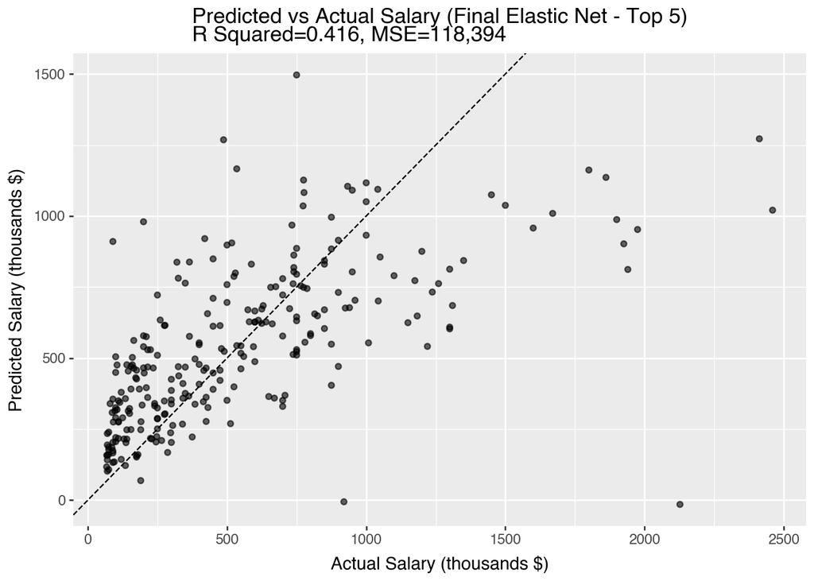

```python
plot_df = pd.DataFrame({
    'Actual': y,
    'Predicted': y_pred,
})

(ggplot(plot_df, aes(x='Actual', y='Predicted'))
 + geom_point(alpha=0.6)
 + geom_abline(intercept=0, slope=1, linetype='dashed')
 + labs(title=f'Predicted vs Actual Salary (Final Elastic Net - Top 5)\nR Squared={r2:.3f}, MSE={mse:,.0f}',
        x='Actual Salary (thousands $)', y='Predicted Salary (thousands $)')
)
```

Among the most important standardized coefficients, Hits(Number of hits in 1986, 173.5) and Career Runs(Number of runs during his career, 156.5) have the strongest positive effects on predicted salary, while At Bats(Number of times at bat in 1986, –33.3) exerts the largest negative influence.

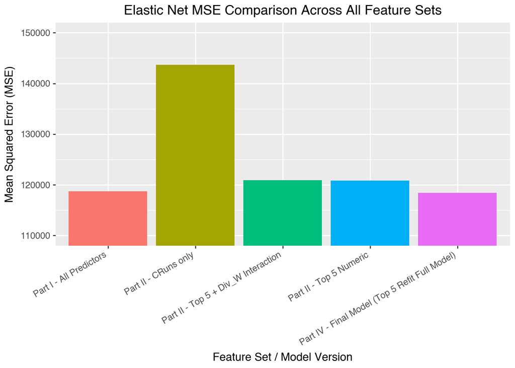

```python
elastic_rows = [
    ("Part I - All Predictors", float(mse_elastic.mean())),
    ("Part II - CRuns only",    mse_elastic_numeric),
    ("Part II - Top 5 Numeric", mse_elastic_top5),
    ("Part II - Top 5 + Div_W Interaction", mse_elastic_interaction),
    ("Part IV - Final Model (Top 5 Refit Full Model)", mse)
]

elastic_df = pd.DataFrame(elastic_rows, columns=["Feature Set", "MSE"]).round(2)

(ggplot(elastic_df, aes(x="Feature Set", y="MSE", fill="Feature Set"))
 + geom_col(show_legend=False)
 + labs(title="Elastic Net MSE Comparison Across All Feature Sets",
        x="Feature Set / Model Version",
        y="Mean Squared Error (MSE)")
+ coord_cartesian(ylim=(110000,150000)) #zooms in on these values of y
 + theme(axis_text_x=element_text(rotation=30, ha="right")))
```